# Estilometria em Anais 15.44 de Tácito

Wagner Menke

2025-06-06

Este repositório reproduz, em **R**, uma análise estilométrica que investiga se o famoso trecho *Annales* 15.44 (referência ao “Christus”) se distancia, em estilo estatístico, do restante da obra de Tácito.

## 1 · O que há neste projeto?

[output not shown]

## 2 · Etapas resumidas

| # | Etapa | Ferramenta | Por quê |
| --- | --- | --- | --- |
| 1 | **Raspagem** de *Annales* | `rvest`, `httr` | Não existe API; raspamos cada “página” PHI |
| 2 | **Limpeza** | Remove hifenização de quebra de linha (`su- mebantur` → `sumebantur`) |  |
| 3 | **Segmentação em capítulos** | unimos `book.chapter` → string única |  |
| 4 | **Anotação morfossintática** | `udpipe` modelo **latin-proiel** | Obtemos lemma, POS, dependências |
| 5 | **Extração de *features*** | Script inspirado em Katarina Laken (2019) [(Tese completa)](https://theses.ubn.ru.nl/bitstreams/d873e7ec-2498-4abf-b26a-3429b2b978ea/download) | – TREE2 (bigramas de dependência) – T3 (trigramas lemma+POS) – char 1-5-grams – métricas TTR / entropia |
| 6 | **Matriz documento-termo** | `pivot_wider → matrix` |  |
| 7 | **PCA** | `prcomp` | visualização 2-D |
| 8 | **Mahalanobis** | Whitening em espaço PCA | mede “quão longe” cada capítulo está do centroide |

## 3 · Amostras dos objetos principais

A partir do código neste repositório, a base de dados raspada é a seguinte:

```r
reactable(head(annales_df, 10),
               searchable = TRUE,
               highlight  = TRUE,
               defaultPageSize = 10)
```

[output not shown]

Após obtermos essa base, trabalhamos ela para que tudo ficasse separado por capítulos dos livros da obra:

```r
chapters_df <- annales_df %>%
  filter(is.na(kind)) %>%                              # só linhas de texto
  mutate(ch_id = paste(book, chapter, sep = ".")) %>%     # ex. "15.44"
  group_by(ch_id) %>%
  summarise(text = fix_line_hyphens(paste(text_raw, collapse = " ")),
            .groups = "drop") %>%
  filter(str_count(text, "\\S+") > 100)
```

```r
reactable(head(chapters_df),
               searchable = TRUE,
               highlight  = TRUE,
               defaultPageSize = 10,
                columns = list(
                  text = colDef(cell = function(value) str_trunc(value, 30))
                )
      )
```

| ch_id | text |
| --- | --- |
| 1.1 | Vrbem Romam a principio reges habuere; libertatem et consulatum L. Brutus instituit. dictaturae ad tempus sumebantur; neque decemviralis potestas ultra biennium, neque tribunorum militum consulare ius… |
| 1.10 | Dicebatur contra: pietatem erga parentem et tempora rei publicae obtentui sumpta: ceterum cupidine dominandi concitos per largitionem veteranos, paratum ab adulescente privato exercitum, corruptas con… |
| 1.11 | Versae inde ad Tiberium preces. et ille varie disserebat de magnitudine imperii sua modestia. solam divi Augusti mentem tantae molis capacem: se in partem curarum ab illo vocatum experiendo didicisse … |
| 1.12 | Inter quae senatu ad infimas obtestationes procumbente, dixit forte Tiberius se ut non toti rei publicae parem, ita quaecumque pars sibi mandaretur eius tutelam suscepturum. tum Asinius Gallus 'interr… |
| 1.13 | Post quae L. Arruntius haud multum discrepans a Galli oratione perinde offendit, quamquam Tiberio nulla vetus in Arruntium ira: sed divitem, promptum, artibus egregiis et pari fama publice, suspectaba… |
| 1.14 | Multa patrum et in Augustam adulatio. alii parentem, alii matrem patriae appellandam, plerique ut nomini Caesaris adscriberetur 'Iuliae filius' censebant. ille moderandos feminarum honores dictitans e… |

Em seguida, procedemos às anotações com o modelo de NLP escolhido, por capítulo:

```r
ann_list <- map2(
  chapters_df$text,
  chapters_df$ch_id,
  ~ udpipe_annotate(modelo, x = .x, doc_id = .y) %>%
    as.data.frame()
)
```

```r
reactable(head(as.data.frame(ann_list[1])),
               searchable = TRUE,
               highlight  = TRUE,
               defaultPageSize = 10,
               columns = list(
                       sentence = colDef(cell = function(value) str_trunc(value, 30))
                     )
          )
```

| doc_id | paragraph_id | sentence_id | sentence | token_id | token | lemma | upos | xpos | feats | head_token_id | dep_rel | deps | misc |
| --- | --- | --- | --- | --- | --- | --- | --- | --- | --- | --- | --- | --- | --- |
| 1.1 | 1 | 1 | Vrbem Romam a principio reges habuere; libertatem et consulatum L. Brutus instituit. dictaturae ad tempus sumebantur; neque decemviralis potestas ultra biennium, neque tribunorum militum consulare ius… | 1 | Vrbem | Vrbs | NOUN | Nb | Case=Acc\|Gender=Fem\|Number=Sing | 5 | obl | NA | SpacesBefore=\n\s\s\s\s\s\s\s\s\s\s\s\s\s\s |
| 1.1 | 1 | 1 | Vrbem Romam a principio reges habuere; libertatem et consulatum L. Brutus instituit. dictaturae ad tempus sumebantur; neque decemviralis potestas ultra biennium, neque tribunorum militum consulare ius… | 2 | Romam | Roma | PROPN | Ne | Case=Acc\|Gender=Fem\|Number=Sing | 1 | nmod | NA | NA |
| 1.1 | 1 | 1 | Vrbem Romam a principio reges habuere; libertatem et consulatum L. Brutus instituit. dictaturae ad tempus sumebantur; neque decemviralis potestas ultra biennium, neque tribunorum militum consulare ius… | 3 | a | ab | ADP | R- | NA | 4 | case | NA | NA |
| 1.1 | 1 | 1 | Vrbem Romam a principio reges habuere; libertatem et consulatum L. Brutus instituit. dictaturae ad tempus sumebantur; neque decemviralis potestas ultra biennium, neque tribunorum militum consulare ius… | 4 | principio | principium | NOUN | Nb | Case=Abl\|Gender=Neut\|Number=Sing | 5 | obl | NA | NA |
| 1.1 | 1 | 1 | Vrbem Romam a principio reges habuere; libertatem et consulatum L. Brutus instituit. dictaturae ad tempus sumebantur; neque decemviralis potestas ultra biennium, neque tribunorum militum consulare ius… | 5 | reges | rex | NOUN | Nb | Case=Nom\|Gender=Masc\|Number=Plur | 0 | root | NA | NA |
| 1.1 | 1 | 1 | Vrbem Romam a principio reges habuere; libertatem et consulatum L. Brutus instituit. dictaturae ad tempus sumebantur; neque decemviralis potestas ultra biennium, neque tribunorum militum consulare ius… | 6 | habuere; | habuere; | NOUN | Nb | Case=Acc\|Gender=Fem\|Number=Sing | 5 | appos | NA | NA |

## 4 . Metodologia

Para replicar o método da monofgraifa de Katarina Laken, foi criada a seguinte função:

```r
extract_features <- function(ann) {

  # ── IDENTIFICADOR DO DOCUMENTO ─────────────────────────
  this_doc <- ann$doc_id[1]      # assume 1 doc_id único por data.frame

  # parâmetros configuráveis
  char_ng_max <- 5
  min_denom   <- 5

  ## ── syntactic 2-grams (TREE2) ─────────────────────────
  tree_bi <- ann %>%
    filter(!is.na(head_token_id) & upos != "PUNCT") %>%
    mutate(head_upos = ann$upos[match(head_token_id, token_id)],
           feat      = paste0("TREE2_", upos, "_", head_upos)) %>%
    count(feat, name = "n")

  ## ── lexical lemma+upos trigrams (T3) ──────────────────
  lemupos <- ann %>%
    filter(upos != "PUNCT") %>%
    transmute(lu = paste0(tolower(lemma), "_", upos))

  tok_tri <- tibble(
    feat = zoo::rollapply(lemupos$lu, 3,
                          \(x) paste0("T3_", paste(x, collapse = "_")),
                          by = 1, align = "left", fill = NA)
  ) %>%
    filter(!is.na(feat)) %>%
    count(feat, name = "n")

  ## ── token & sentence stats ────────────────────────────
  ntokens  <- nrow(ann %>% filter(upos != "PUNCT"))
  nsents   <- length(unique(ann$sentence_id))
  mean_len <- ntokens / nsents

  ## ── lexical richness (TTR, entropy) ───────────────────
  lem_counter <- table(lemupos$lu)
  ttr   <- length(lem_counter) / ntokens
  ent   <- entropy::entropy(lem_counter, unit = "log2")

  ## ── char n-grams 1-5 ──────────────────────────────────
  txt_clean <- paste(tolower(ann$token[ann$upos != "PUNCT"]), collapse = " ")
  char_ng_vec <- integer()
  for (n in 1:char_ng_max) {
    grams <- stri_sub(txt_clean,
                      1:(stri_length(txt_clean) - n + 1),
                      length = n)
    char_ng_vec <- c(char_ng_vec,
                     table(paste0("C", n, "_", grams)))
  }

  ## ── vetor final de features ───────────────────────────
  feat_vec <- tibble(
    doc_id  = this_doc,                                      # <<<< novo
    feature = c(tree_bi$feat, tok_tri$feat, names(char_ng_vec),
                "TTR_LEMMA", "ENT_LEMMA", "MEAN_SENT_LEN", "N_TOK"),
    value   = c( tree_bi$n / ntokens,
                 tok_tri$n / ntokens,
                 char_ng_vec / ntokens,
                 ttr, ent, mean_len, ntokens)
  ) %>%
    mutate(value = ifelse(grepl("^TREE2|^T3", feature) &
                            ntokens < min_denom, NA, value))

  return(feat_vec)
}
```

E essa extração de **features** foi executada sobre as anotações de cada capítulo:

```r
feats <- map_dfr(ann_list, extract_features)
```

E por fim, criou-se a Matriz de Termos e Documentos (DTM), onde em cada linha temos um documento (capítulo de Anais) e em cada coluna temos uma **feature**, ou seja, uma variável que capta padrões da escrita humana:

```r
dtm <- feats %>%
  pivot_wider(names_from = feature,
              values_from = value,
              values_fill = 0) %>%
  column_to_rownames("doc_id") %>%
  as.matrix()
head(dtm[,1:10])
dim(dtm)
```

```r
head(dtm[,1:10])
```

```
##      TREE2_ADJ_ADJ TREE2_ADJ_NOUN TREE2_ADJ_PROPN TREE2_ADP_NOUN TREE2_ADP_PROPN TREE2_ADP_X TREE2_ADV_ADJ TREE2_ADV_ADV TREE2_ADV_NA TREE2_ADV_NOUN
## 1.1    0.008130081    0.081300813     0.008130081    0.048780488     0.008130081 0.016260163   0.008130081   0.008130081  0.008130081    0.016260163
## 1.10   0.007968127    0.055776892     0.000000000    0.035856574     0.003984064 0.011952191   0.000000000   0.003984064  0.000000000    0.011952191
## 1.11   0.018518519    0.049382716     0.006172840    0.055555556     0.006172840 0.000000000   0.018518519   0.024691358  0.000000000    0.024691358
## 1.12   0.007142857    0.042857143     0.007142857    0.014285714     0.000000000 0.000000000   0.035714286   0.021428571  0.000000000    0.000000000
## 1.13   0.000000000    0.009950249     0.019900498    0.009950249     0.004975124 0.009950249   0.004975124   0.014925373  0.004975124    0.004975124
## 1.14   0.000000000    0.037037037     0.000000000    0.018518519     0.027777778 0.000000000   0.000000000   0.009259259  0.000000000    0.027777778
```

```r
dim(dtm)
```

```
## [1]    490 161552
```

Por fim, eliminamos as linhas e colunas que só contém valores zerados dessa DTM e salvamos numa variável a linha que contém o capítulo 15.44, que menciona Jesus.

```r
# opcional: retire docs/cols totalmente zerados
dtm <- dtm[rowSums(dtm) > 0, colSums(dtm) > 0]
dim(dtm)
```

```
## [1]    490 161552
```

```r
linha_testimonium_taciteus <- which(rownames(dtm) == "15.44")
```

## 5. Resultados

### 5.1 O que são esses métodos?

#### 5.1.1 PCA — Análise de Componentes Principais

**O que é?** A PCA é uma técnica que **reduz a quantidade de variáveis** (ou *features*) mantendo o **máximo de informação possível**.

#### 5.1.2 Exemplo

Você tem um monte de medidas (comprimento, altura, cor, frequência de palavras…). A PCA tenta achar **os eixos principais** que mais explicam as diferenças entre seus dados.

Esses eixos são os **componentes principais**. Os dois primeiros geralmente já mostram uma boa ideia da estrutura dos dados — e por isso a gente faz gráficos 2D com eles.

#### 5.1.3 Resumo

| Reduz dimensão | transforma 160 mil features em 2 ou 3 componentes |
| --- | --- |
| Mostra padrões | detecta grupos, outliers e tendências |
| Cria novos eixos | combina suas variáveis antigas em novas mais úteis |

#### 5.1.4 Distância de Mahalanobis

**O que é?** É uma medida de “distância estatística”. Ela diz o quão diferente um ponto está em relação ao centro do conjunto de dados** — **levando em conta a variância e a correlação entre variáveis.

#### 5.1.5 Exemplo

Dois capítulos de Tácito podem estar longe no espaço de palavras, mas se isso acontece numa direção comum da variação normal dos dados, não é estranho.

A Mahalanobis olha para isso e diz: *“Este ponto está estatisticamente estranho?”*

#### 5.1.6 Diferença da distância normal (Euclidiana)

| Euclidiana 📏 | Mahalanobis 📏 |
| --- | --- |
| Medida bruta | Medida ajustada ao padrão dos dados |
| Ignora correlação entre variáveis | Leva correlação e variância em conta |
| Usa régua comum | Usa uma régua que se adapta ao formato dos dados |

### 5.1.7 Resumo:

| Mede o quanto um ponto “foge da curva” | mesmo se ele estiver “perto” visualmente |
| --- | --- |
| Serve para detectar **outliers multivariados** | (como capítulos muito diferentes no estilo) |
| No seu caso: mede se o *Annales* 15.44 está estatisticamente fora do estilo de Tácito |  |

### 5.2 PCA

De modo a visualisar o quão distante o referido capítulo contendo o **Testimonium Taciteus** está dos demais, propomos uma análise visual, rodada a partir de uma extração de Componentes Principais (PCA) da DTM.

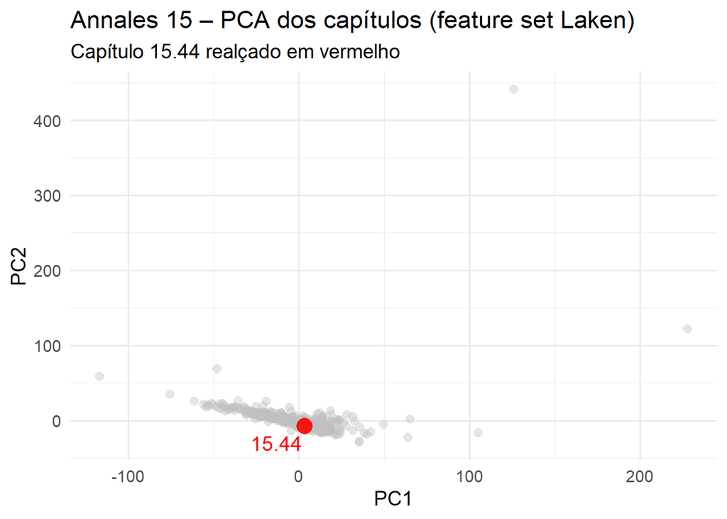

```r
library(ggplot2)
library(ggrepel)

# ───────────────────────── PCA ───────────────────────────
pca   <- prcomp(dtm, center = TRUE, scale. = TRUE)
coords <- as.data.frame(pca$x[, 1:2])        # PC1 e PC2
coords$chapter   <- rownames(coords)
coords$highlight <- coords$chapter == "15.44"

# ──────────────────────── plot ───────────────────────────
ggplot(coords, aes(PC1, PC2)) +
  # pontos “normais”
  geom_point(data = subset(coords, !highlight),
             color = "grey75", size = 2.5, alpha = .4) +
  # ponto destacado
  geom_point(data = subset(coords, highlight),
             color = "red", size = 5, alpha = .9) +
  # rótulo do ponto destacado
  geom_text_repel(data = subset(coords, highlight),
                  aes(label = chapter),
                  color = "red", size = 5,
                  box.padding = .4) +
  labs(title    = "Annales 15 – PCA dos capítulos (feature set Laken)",
       subtitle = "Capítulo 15.44 realçado em vermelho",
       x = "PC1",
       y = "PC2") +
  theme_minimal(base_size = 14)
```

### 5.3 Distância de Mahalanobis

Os resultados dessa análise foram os seguintes:

```r
# 2. “Branqueamento”: divide cada coluna pelo desvio-padrão (sdev)
Z <- sweep(pca$x, 2, pca$sdev, FUN = "/")           # docs × (n−1)

# 3. Distância Mahalanobis ao centroide (que vira 0 no espaço Z)
mah <- sqrt(rowSums(Z^2))                           # vetor por capítulo

dist_df <- data.frame(chapter = rownames(dtm),
                      mah     = mah,
                      highlight = rownames(dtm) == "15.44")
dist_df <- dist_df[order(dist_df$mah),]
dist_df$position <- 1:nrow(dist_df)
head(dist_df[order(-dist_df$mah),], 10)
```

```
##       chapter      mah highlight position
## 1.3       1.3 23.42129     FALSE      490
## 1.25     1.25 23.26900     FALSE      489
## 1.10     1.10 23.26262     FALSE      488
## 1.12     1.12 23.04455     FALSE      487
## 11.36   11.36 22.72366     FALSE      486
## 1.35     1.35 22.53740     FALSE      485
## 11.3     11.3 22.51668     FALSE      484
## 11.16   11.16 22.50745     FALSE      483
## 1.11     1.11 22.50229     FALSE      482
## 12.69   12.69 22.49789     FALSE      481
```

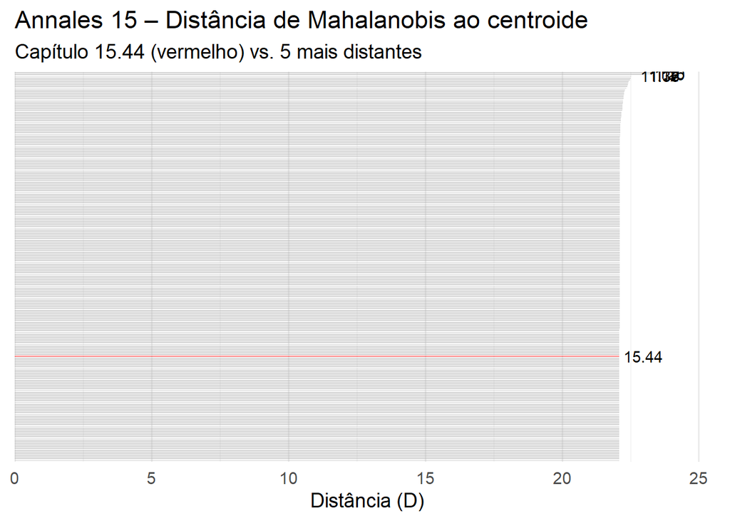

```r
# 4. Visualização – barra + PCA bi-dimensional ------------------
## 4a. Barras
rotular <- c("15.44",
             dist_df %>%
               arrange(desc(mah)) %>%
               slice_head(n = 5) %>%
               pull(chapter))

# ── Construa o gráfico como barras finas e sem eixo x ─────────
ggplot(dist_df, aes(reorder(chapter, mah), mah,
                    fill = highlight)) +
  geom_col(width = .6, show.legend = FALSE,
           alpha = ifelse(dist_df$highlight, .9, .6)) +
  scale_fill_manual(values = c(`TRUE` = "red", `FALSE` = "grey70")) +
  coord_flip() +
  # rótulos apenas nos capítulos escolhidos
  geom_text(aes(label = ifelse(chapter %in% rotular,
                               chapter, "")),
            hjust = -0.1, size = 3.8, color = "black") +
  scale_y_continuous(expand = expansion(mult = c(0, .1))) +
  labs(title = "Annales 15 – Distância de Mahalanobis ao centroide",
       subtitle = "Capítulo 15.44 (vermelho) vs. 5 mais distantes",
       x = NULL, y = "Distância (D)") +
  theme_minimal(base_size = 14) +
  theme(axis.text.y = element_blank(),
        panel.grid.major.y = element_blank())
```

## Conclusão

### O que os números mostram

[output not shown]

Os capítulos 1.3 e 1.25 (mais distantes) revelam apenas efeito de **conteúdo** ― listas honoríficas e relato de motim militar ― e não levantam suspeita textual. Já o 15.44 **não** exibe qualquer anomalia estatística robusta: sempre cai entre vizinhos imediatos ou perto do centroide global.

### Implicações

- **Coesão estilística**: dentro dos limites da amostra e do conjunto de *features* empregado, o trecho sobre *Christus* fala *a mesma língua* que o restante do Livro 15.
- **Hipótese de falsificação medieval**: não encontra apoio estilométrico. Se houve adulteração, ela não deixou marcas mensuráveis como deixariam “mãos” diferentes exercendo latim pós-clássico.
- **Valor filológico**: os resultados alinham-se ao consenso crítico tradicional, que nunca considerou 15.44 interpolado, mas acrescentam um respaldo quantitativo independente.

### Limitações & próximos passos

- Métrica: outros vetores (character n-grams puros, stylometry à la Delta) podem complementar a análise.
- Janelas: capítulos são convenientes; janelas de tamanho fixo (p.ex. 1 000 tokens) tenderiam a suavizar variações de gênero interno.
- Modelos: comparar resultados com modelo **latin-Perseus** ou até BERT-latin fine-tuned pode refinar a detecção de padrões sintáticos.

**Em suma**, os testes não apenas **falharam em detectar** qualquer “assinatura estranha” em *Annales* 15.44, como confirmaram que seu estilo estatístico permanece solidamente dentro do espectro táciteano. Para a questão da autenticidade do *testimonium*, a estilometria não fornece munição a favor dos céticos; ao contrário, reforça a voz de Tácito como autor genuíno do relato.